# STAT 184 Final Project: Exploratory Data Analysis

Jordan Williard

April 7th, 2020

# Guiding Question (i.e., Research Question): Make a clear statement of a single guiding/research question that will drive your analysis. It should be phrased as a question that you will try to investigate (i.e., it should have a question mark)

How has the landscape of American political ideology changed throughout the past 100 years? Which states have experienced the most change? Are there any notable long term trends?

# Become acquainted with your data sources:

- Where did you find them?

  Data Source 1: Comparative Political Dataset (https://www.cpds-data.org/). I found this by searching and comparing various political datasets.

  Data Source 2: US Population by Zip Code (https://data.world/lukewhyte/us-population-by-zip-code-2010-2016. I want to include demographic data in this analysis. This dataset has a good cross section of years leading up to present day politics.
- Who collected/maintains them?

  Data Source 1 is maintained by Prof. Dr. Klaus Armingeon and collaborators at the University of Zurich.

  Data Source 2 was aggregated by a user on data.world. The data comes from 5-year American Surveys and the 2010 Decennial Census
- When & Why were they originally collected?

  The data in Data Source 1, the CPDS, has been collected since 1960 in many democratic countries. The goal is to better understand the political landscape of democratic countries across the globe. I’ll be focusing on the United States.

  The data in Data Source 2 has been collected by the United States government for demographic purposes. These surveys allow the government to better understand who and where people are living.
- What does a case represent in each data source, and how many total cases are available?

  In Data Source 1, a case represents the political, social, and demographic information for one country, during one year.

  In Data Source 2, a case represents the population of a zip code for years 2010-2016.
- What are some of the variables that you plan to use

  Data Source 1 has over 300 columns, so I will need to be selective with what I use. That being said, I am most interested in understanding changes in the American political system as well as what opinions may be causing them. So, to start I am going to use: Total population, elderly population, political spectrums (varying categorical degrees of left –> right), religion metrics, and protest information (could be indicative of unrest/revolution). This is just a start and I imagine that I’ll end up using many more.

  Simply put, I’m going to use all of the variables from Data Source 2. This data is extremely narrow, but will allow me to better understand demographic transitions across regions of the United States. So, I will be using the Zip Code variable as well as all 7 years of population information.

# Explore intuition related to the research question

### Loading Data

```r
library(DataComputing)
CPDS <- read.csv("CPDS-1960-2017-Update-2019.csv")
ZipPop <- read.csv("pop-by-zip-code.csv")
head(CPDS)
```

|  | year | country | countryn | iso | iso3n | cpds1 | poco | eu | emu | gov_right1 | gov_cent1 | gov_left1 | gov_party | gov_new | gov_gap | gov_chan | gov_right2 | gov_cent2 | gov_left2 | gov_right3 | gov_cent3 | gov_left3 | gov_sup | gov_type | year_01 | country_01 | elect | vturn | social1 | … |
| --- | --- | --- | --- | --- | --- | --- | --- | --- | --- | --- | --- | --- | --- | --- | --- | --- | --- | --- | --- | --- | --- | --- | --- | --- | --- | --- | --- | --- | --- | --- |
| 1 | 1960 | Australia | 1 | AUS | 36 | 1 | 0 | 0 | 0 | 100 | 0 | 0 | 1 | 0 | 0 | 0 | 100 | 0 | 0 | 63.10 | 0 | 0 | 63.10 | 2 | 1960 | Australia |  | 95.5 | 42.8 | … |
| 2 | 1961 | Australia | 1 | AUS | 36 | 1 | 0 | 0 | 0 | 100 | 0 | 0 | 1 | 0 | 0 | 1 | 100 | 0 | 0 | 62.80 | 0 | 0 | 62.80 | 2 | 1961 | Australia | 12/9/1961 | 95.3 | 47.9 | … |
| 3 | 1962 | Australia | 1 | AUS | 36 | 1 | 0 | 0 | 0 | 100 | 0 | 0 | 1 | 0 | 0 | 0 | 100 | 0 | 0 | 50.80 | 0 | 0 | 50.80 | 2 | 1962 | Australia |  | 95.3 | 47.9 | … |
| 4 | 1963 | Australia | 1 | AUS | 36 | 1 | 0 | 0 | 0 | 100 | 0 | 0 | 1 | 0 | 0 | 1 | 100 | 0 | 0 | 51.14 | 0 | 0 | 51.14 | 2 | 1963 | Australia | 11/30/1963 | 95.7 | 45.5 | … |
| 5 | 1964 | Australia | 1 | AUS | 36 | 1 | 0 | 0 | 0 | 100 | 0 | 0 | 1 | 0 | 0 | 0 | 100 | 0 | 0 | 59.00 | 0 | 0 | 59.00 | 2 | 1964 | Australia |  | 95.7 | 45.5 | … |
| 6 | 1965 | Australia | 1 | AUS | 36 | 1 | 0 | 0 | 0 | 100 | 0 | 0 | 1 | 0 | 0 | 0 | 100 | 0 | 0 | 59.00 | 0 | 0 | 59.00 | 2 | 1965 | Australia |  | 95.7 | 45.5 | … |

```r
head(ZipPop)
```

|  | zip_code | y.2016 | y.2015 | y.2014 | y.2013 | y.2012 | y.2011 | y.2010 | aggregate |
| --- | --- | --- | --- | --- | --- | --- | --- | --- | --- |
| 1 | 601 | 17800 | 17982 | 18088 | 18450 | 18544 | 18533 | 18570 | 127967 |
| 2 | 602 | 39716 | 40260 | 40859 | 41302 | 41640 | 41930 | 41520 | 287227 |
| 3 | 603 | 51565 | 52408 | 53162 | 53683 | 54540 | 54475 | 54689 | 374522 |
| 4 | 606 | 6320 | 6331 | 6415 | 6591 | 6593 | 6386 | 6615 | 45251 |
| 5 | 610 | 27976 | 28328 | 28805 | 28963 | 29141 | 29111 | 29016 | 201340 |
| 6 | 612 | 63884 | 64816 | 66251 | 68055 | 69017 | 70541 | 67010 | 469574 |

- Create some informative plots and summary statistics

CPDS: Simple summary statisitcs

```r
CPDS <-
  CPDS %>%
  select(year, country, realgdpgr, inflation, pop, elderly) %>%
  filter(country == "USA")
summary(CPDS)
```

```
      year           country     realgdpgr        inflation           pop            elderly
 Min.   :1960   USA      :58   Min.   :-2.780   Min.   :-0.360   Min.   :180760   Min.   : 9.22
 1st Qu.:1974   Australia: 0   1st Qu.: 1.887   1st Qu.: 1.942   1st Qu.:214419   1st Qu.:10.36
 Median :1988   Austria  : 0   Median : 3.240   Median : 3.025   Median :246224   Median :12.31
 Mean   :1988   Belgium  : 0   Mean   : 3.072   Mean   : 3.776   Mean   :251568   Mean   :11.77
 3rd Qu.:2003   Bulgaria : 0   3rd Qu.: 4.460   3rd Qu.: 4.298   3rd Qu.:289958   3rd Qu.:12.60
 Max.   :2017   Canada   : 0   Max.   : 7.260   Max.   :13.550   Max.   :325983   Max.   :15.60
                (Other)  : 0   NA's   :2
```

```r
CPDS$year[CPDS$inflation == min(CPDS$inflation)]
```

```
[1] 2009
```

```r
CPDS$year[CPDS$realgdpgr == min(CPDS$realgdpgr, na.rm = TRUE)]
```

```
[1]   NA 2009   NA
```

```r
CPDS$year[CPDS$elderly == max(CPDS$elderly, na.rm = TRUE)]
```

```
[1] 2017
```

```r
CPDS$year[CPDS$elderly == min(CPDS$elderly, na.rm = TRUE)]
```

```
[1] 1960
```

ZipPop: Simple summary statisitcs

```r
summary(ZipPop)
```

```
    zip_code         y.2016           y.2015             y.2014           y.2013           y.2012             y.2011           y.2010         aggregate
 Min.   :  601   Min.   :     0   Min.   :     0.0   Min.   :     0   Min.   :     0   Min.   :     0.0   Min.   :     0   Min.   :     0   Min.   :     0
 1st Qu.:26635   1st Qu.:   718   1st Qu.:   718.8   1st Qu.:   717   1st Qu.:   721   1st Qu.:   720.8   1st Qu.:   716   1st Qu.:   734   1st Qu.:  5037
 Median :49739   Median :  2808   Median :  2808.0   Median :  2806   Median :  2802   Median :  2786.0   Median :  2792   Median :  2806   Median : 19636
 Mean   :49666   Mean   :  9724   Mean   :  9664.4   Mean   :  9593   Mean   :  9517   Mean   :  9445.6   Mean   :  9370   Mean   :  9434   Mean   : 66749
 3rd Qu.:72124   3rd Qu.: 13178   3rd Qu.: 13139.2   3rd Qu.: 13066   3rd Qu.: 13000   3rd Qu.: 12952.0   3rd Qu.: 12838   3rd Qu.: 12943   3rd Qu.: 91210
 Max.   :99929   Max.   :115104   Max.   :114982.0   Max.   :115013   Max.   :114734   Max.   :115538.0   Max.   :114941   Max.   :113916   Max.   :797117
```

```r
mean(ZipPop$y.2010)
```

```
[1] 9434.269
```

```r
mean(ZipPop$y.2016)
```

```
[1] 9724.409
```

```r
ZipPopMean <-
  ZipPop %>%
  mutate("mean2010" = mean(y.2010),
         "mean2011" = mean(y.2011),
         "mean2012" = mean(y.2012),
         "mean2013" = mean(y.2013),
         "mean2014" = mean(y.2014),
         "mean2015" = mean(y.2015),
         "mean2016" = mean(y.2016),
         ) %>%
  select(mean2010, mean2011, mean2012, mean2013, mean2014, mean2015, mean2016)
 avg_sizes <- ZipPopMean[!duplicated(ZipPopMean$mean2010),]

 avg_sizes
```

|  | mean2010 | mean2011 | mean2012 | mean2013 | mean2014 | mean2015 | mean2016 |
| --- | --- | --- | --- | --- | --- | --- | --- |
| 1 | 9434.269 | 9369.843 | 9445.568 | 9516.96 | 9593.275 | 9664.375 | 9724.409 |

CPDS: Simple Graphs

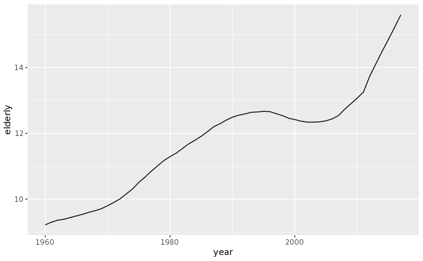

```r
CPDS %>%
  ggplot(aes(x=year, y=elderly)) +
  geom_line()
```

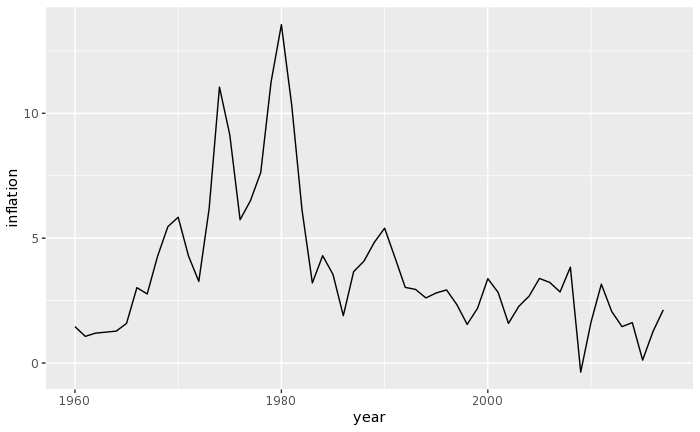

```r
CPDS %>%
  ggplot(aes(x=year, y=inflation)) +
  geom_line()
```

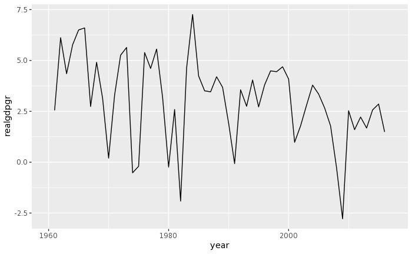

```r
CPDS %>%
  ggplot(aes(x=year, y=realgdpgr)) +
  geom_line()
```

- Describe preliminary observations and intuition about the research question

[output not shown]